# Homework 4

**Due Date:** 2024-11-13 at 8:30 AM PT

**Name:** Sabahat

## Preparation

1. Download the [data file](https://github.com/gabehassler/PRGS-Intro-to-ML-2024/blob/main/data/processed/svi_covid.csv) from GitHub and place it in the *data/processed* folder.

#`Done`

## Homework - Regression Trees

The goal of this analysis is to use a regression tree to predict the number of per-capita COVID-19 deaths in each county in the US using the SVI variables.

#importing extensions

```python
import pandas as pd
from sklearn.tree import DecisionTreeRegressor
from sklearn.metrics import mean_squared_error
from sklearn.model_selection import KFold
import numpy as np
import matplotlib.pyplot as plt
from sklearn.tree import DecisionTreeRegressor, plot_tree
```

1. Load the data file. #loading data file

```python
if __name__ == "__main__":
 # Specify the file path as a string

   file_path = "C:/Users/sabahat/Desktop/ML-Folder/Sabahat-PRGS-Intro-to-ML-2024/data/processed/svi_covid.csv"
# Function to load the data
def load_data(file_path):
    return pd.read_csv(file_path)
```

#2. Write the following functions: #A function that fits a regression tree to data. The function should take as input the data, the outcome variable, the predictor variables, and the maximum depth of the tree. The function should return the fitted tree. *Note: Many packages have functions that penalize the complexity of the tree to avoide overfitting. You should make sure that the function you write does not use any penalization for the complexity of the tree.*

#Function to fit a regression tree Initialize and fit the regression tree without complexity penalties.

```python
def fit_regression_tree(data, outcome_var, predictor_vars, max_depth=None):
    X = data[predictor_vars]
    y = data[outcome_var]
    tree = DecisionTreeRegressor(max_depth=max_depth)
    tree.fit(X, y)

    return tree
```

#A function that predicts the outcome variable using a fitted tree. The function should take as input the fitted tree and the data for which to make predictions. The function should return the predicted values.

Function to predict using a fitted tree.

```python
def predict_with_tree(fitted_tree, data):
    return fitted_tree.predict(data)
```

##- A function that calculates the mean squared error of the predictions. The function should take as input the predicted values and the true values. The function should return the mean squared error. #Function to calculate mean squared error

```python
def calculate_mse(predicted_values, true_values):
    return mean_squared_error(true_values, predicted_values)
```

##3. Use 5-fold cross-validation to calculate the mean squared error of the regression tree for maximum tree depths 1, …, 10. The outcome variable is `total_deaths_per_100k` and the predictor variables are `EP_POV150, EP_UNEMP, EP_HBURD, EP_NOHSDP, EP_UNINSUR, EP_AGE65, EP_AGE17, EP_DISABL, EP_SNGPNT, EP_LIMENG, EP_MINRTY, EP_MUNIT, EP_MOBILE, EP_CROWD, EP_NOVEH, EP_GROUPQ, EP_NOINT`. #5-fold cross-validation and calculation of mean square erroe of the regression tree.

```python
# Load the data
file_path = "C:/Users/sabahat/Desktop/ML-Folder/Sabahat-PRGS-Intro-to-ML-2024/data/processed/svi_covid.csv"
data = pd.read_csv(file_path)
outcome_var = "total_deaths_per_100k"
predictor_vars = ["EP_POV150", "EP_UNEMP", "EP_HBURD", "EP_NOHSDP", "EP_UNINSUR",
                  "EP_AGE65", "EP_AGE17", "EP_DISABL", "EP_SNGPNT", "EP_LIMENG",
                  "EP_MINRTY", "EP_MUNIT", "EP_MOBILE", "EP_CROWD", "EP_NOVEH",
                  "EP_GROUPQ", "EP_NOINT"]

def cross_validate_tree(data, outcome_var, predictor_vars, max_depth_range):
    X = data[predictor_vars].values
    y = data[outcome_var].values
    kf = KFold(n_splits=5, shuffle=True, random_state=42)

    mse_scores = {depth: [] for depth in max_depth_range}

    for train_index, test_index in kf.split(X):
        X_train, X_test = X[train_index], X[test_index]
        y_train, y_test = y[train_index], y[test_index]

        for depth in max_depth_range:
            tree = DecisionTreeRegressor(max_depth=depth)
            tree.fit(X_train, y_train)
            predictions = tree.predict(X_test)
            mse = mean_squared_error(y_test, predictions)
            mse_scores[depth].append(mse)

    # Calculate the average MSE for each depth
    average_mse = {depth: np.mean(mse_scores[depth]) for depth in max_depth_range}
    return average_mse

max_depth_range = range(1, 11)
average_mse = cross_validate_tree(data, outcome_var, predictor_vars, max_depth_range)

# Print the results
for depth, mse in average_mse.items():
    print(f"Max Depth: {depth}, Average MSE: {mse:.4f}")
```

```
Max Depth: 1, Average MSE: 26498.8698
Max Depth: 2, Average MSE: 23950.5595
Max Depth: 3, Average MSE: 23385.2192
Max Depth: 4, Average MSE: 23447.9825
Max Depth: 5, Average MSE: 23835.0293
Max Depth: 6, Average MSE: 24089.4054
Max Depth: 7, Average MSE: 25330.1217
Max Depth: 8, Average MSE: 27888.7720
Max Depth: 9, Average MSE: 29274.2241
Max Depth: 10, Average MSE: 29469.0410
```

4. Plot the mean squared error as a function of the maximum tree depth. #Plotting the results.

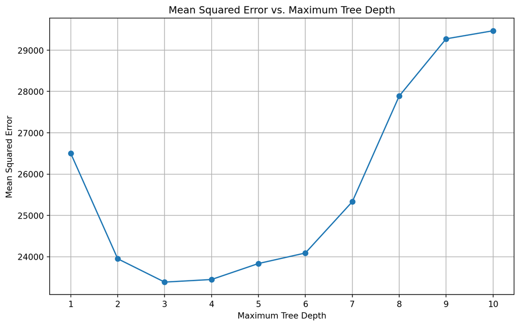

```python
import matplotlib.pyplot as plt
# Plot the results
depths = list(average_mse.keys())
mse_values = list(average_mse.values())

plt.figure(figsize=(10, 6))
plt.plot(depths, mse_values, marker='o', linestyle='-')
plt.title('Mean Squared Error vs. Maximum Tree Depth')
plt.xlabel('Maximum Tree Depth')
plt.ylabel('Mean Squared Error')
plt.xticks(depths)
plt.grid(True)
plt.show()
```

#6. Fit a regression tree to the full data using the maximum tree depth you chose in the previous question.

#Fitting regression tree to full data using the 3 as maximum tree depth

```python
x = data[predictor_vars]
y = data[outcome_var]
tree = DecisionTreeRegressor(max_depth=3)
tree.fit(x, y)
print(f"Tree depth: {tree.get_depth()}")
print(f"Number of leaves: {tree.get_n_leaves()}")
```

```
Tree depth: 3
Number of leaves: 8
```

7. Plot the fitted tree. Summarize the tree in words. What variables seem to be the most important predictors of the number of per-capita COVID-19 deaths? #Plotting the tree

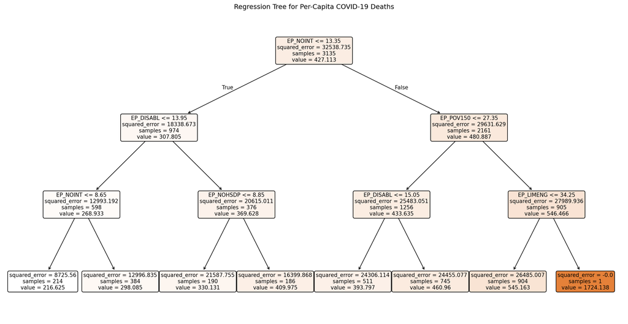

```python
import pandas as pd
from sklearn.tree import DecisionTreeRegressor, plot_tree
import matplotlib.pyplot as plt
plt.figure(figsize=(20, 10))
plot_tree(tree, feature_names=predictor_vars, filled=True, rounded=True)
plt.title('Regression Tree for Per-Capita COVID-19 Deaths')
plt.show()
```

#Answer: As per the Regression Tree, the most important predictor of the number of per-capita COVID-19 deaths is the ‘EP_NOINT’, which is used for the first split. The other important variables are EP_DISABL, EP_POV150, and NP_NOHSDP which are used more oftenly compared to other variables.We can conclude that these variables are the most important predictors of ‘per-capita COVID-19 deaths’ in this dataset.

8. Plot the predicted values against the true values. How much would you trust the predictions of the regression tree? Why?

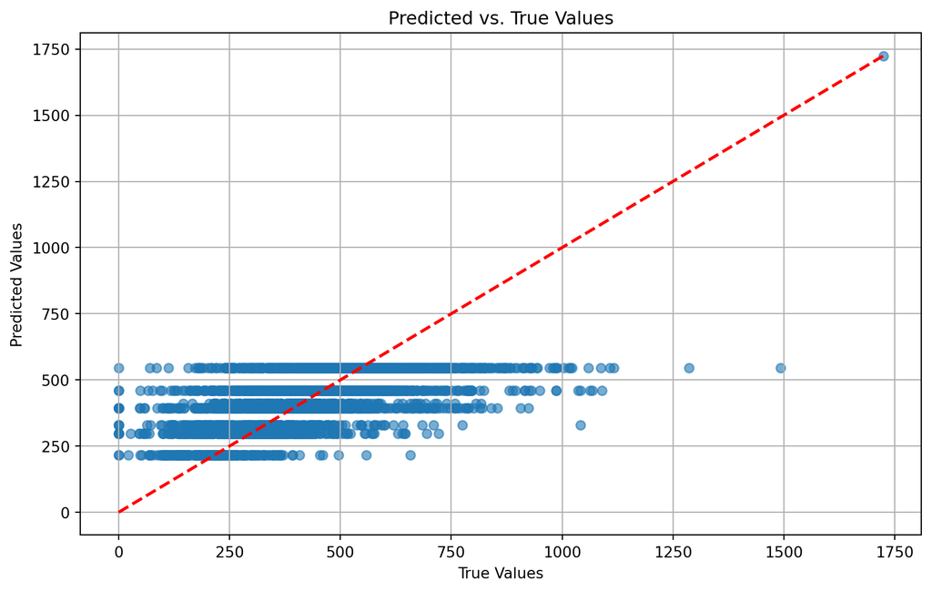

```
Mean Squared Error on full data: 21879.4277
```

```python
predictions = tree.predict(x)
plt.figure(figsize=(10, 6))
plt.scatter(y, predictions, alpha=0.6)
plt.plot([y.min(), y.max()], [y.min(), y.max()], 'r--', lw=2)
plt.xlabel('True Values')
plt.ylabel('Predicted Values')
plt.title('Predicted vs. True Values')
plt.grid(True)
plt.show()
mse = mean_squared_error(y, predictions)
print(f"Mean Squared Error on full data: {mse:.4f}")
```

#Answer: For small errors, the predicted values should be close to the true values, however, the wide spread of points away from red line suggests higher prediction errors. The significant deviation indicates that the model is not reliable to capture complex relationships.

# Disclaimer: I used the Chat GPT to generate codes